# What’s Cooking

Sirui Zhou

12/05/2017

This project is from Kaggle competition. The goal is to distinguish the category of a dish’s cuisine based on a list of its ingredients.

```r
# load packages
library(readr)
library(dplyr)
library(ggplot2)
library(methods)
library(stringi)
library(smodels)
library(tokenizers)
library(wordcloud)
library(viridis)
```

# Know My Data

The data was provided by *Yummly*, a website for users to find their desired recipe. The data is stored in the JSON files. The first step is to use `fromJson` function from the *jsonlite* package to convert the JSON file to a data frame.

```r
library(jsonlite)
recipe <- fromJSON("train.json", flatten = TRUE)
```

As shown, the raw data for ingredients is a char list rather than the textual data. Let’s take a look at the elements in the first list. There are different kinds of ingredients.

```r
recipe$ingredients[1]
```

```
## [[1]]
## [1] "romaine lettuce"      "black olives"         "grape tomatoes"
## [4] "garlic"               "pepper"               "purple onion"
## [7] "seasoning"            "garbanzo beans"       "feta cheese crumbles"
```

To convert the char list to character, I first need to connect the words in one element using functions from *stringi* package and `lapply`, and then unlist the entire list.

```r
temp <- lapply(recipe$ingredients,
       function(v) stri_paste(stri_replace_all(v, "_", fixed = " "), collapse = " "))
recipe$ingredients <- unlist(temp)
```

There are 20 types of cuisines: Among the 39774 observations, almost 8,000 of them are Italian, above 6,000 are Mexican, more than 4000 Southern US, and Indian, French, and Chinese cuisines are around 3,000 each. The rest of them appears below 2,000 times.

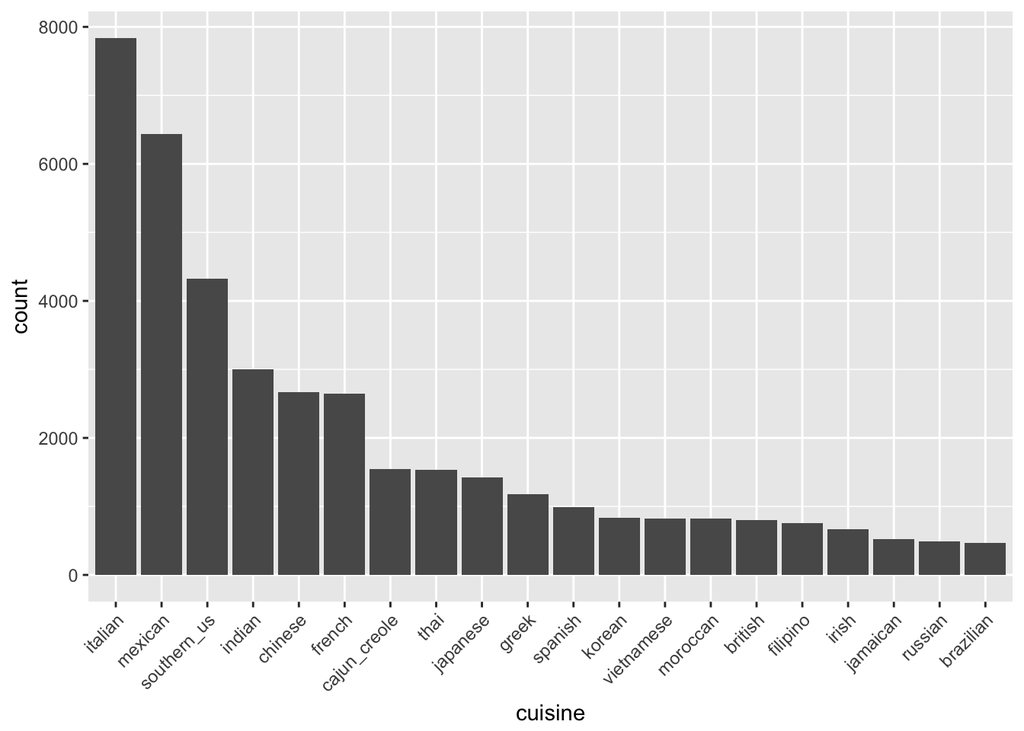

```r
ggplot(data = recipe, aes(x = reorder(cuisine, -table(cuisine)[cuisine]))) + geom_bar() + labs(x = "cuisine", y = "count") + theme(axis.text.x=element_text(angle=45, hjust=1))
```

Then I take each ingredient and created a sparse matrix with only terms that are used in at least 0.1% of the documents but no more than 90% of the documents.

```r
token_list <- tokenize_words(recipe$ingredients)
token_df <- term_list_to_df(token_list)
X <- term_df_to_matrix(token_df,min_df = 0.001, max_df = 0.90, scale = FALSE)
#dim(X)
```

The most frequently appeared ingredients are the commonly used spices.

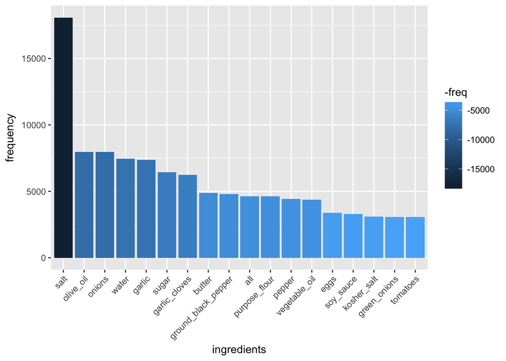

```r
freq <- sort(colSums(as.matrix(X)), decreasing=TRUE)
# Create a frequency bar chart
wf <- data.frame(word=names(freq), freq=freq)

ggplot(subset(wf, freq>3000), aes(x = reorder(word, -freq), y = freq)) +
          geom_bar(stat = "identity", aes(fill = -freq)) + labs(x = "ingredients", y = "frequency") +
          theme(axis.text.x=element_text(angle=45, hjust=1))
```

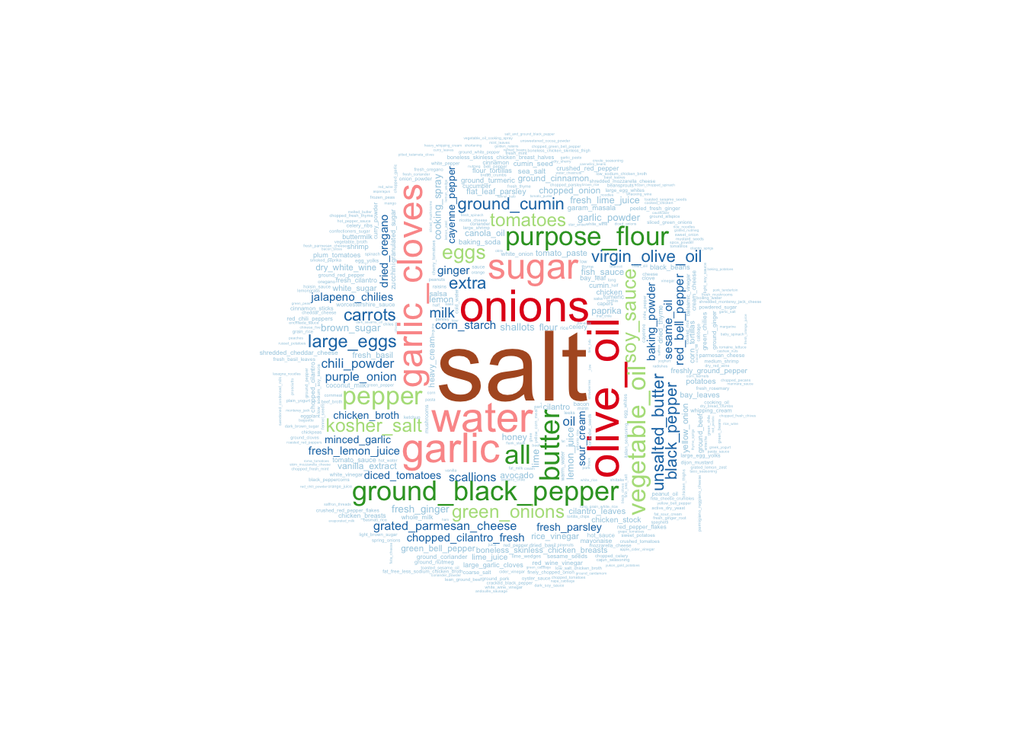

```r
# Create the wordcloud
set.seed(123)
wordcloud(names(freq),
          scale = c(4, 0.1),
          freq,
          min.freq=200,
          max.words = 10000,
          random.order=FALSE, rot.per=.15,
          color= #brewer.pal(8,"Dark2"))
            brewer.pal(12,"Paired"))
```

Let’s take a look at Italian recipes. Many different kinds of cheese appears. Many of the smaller texts are differnt kinds of fresh vegetables.

```
## [1] 7838  874
```

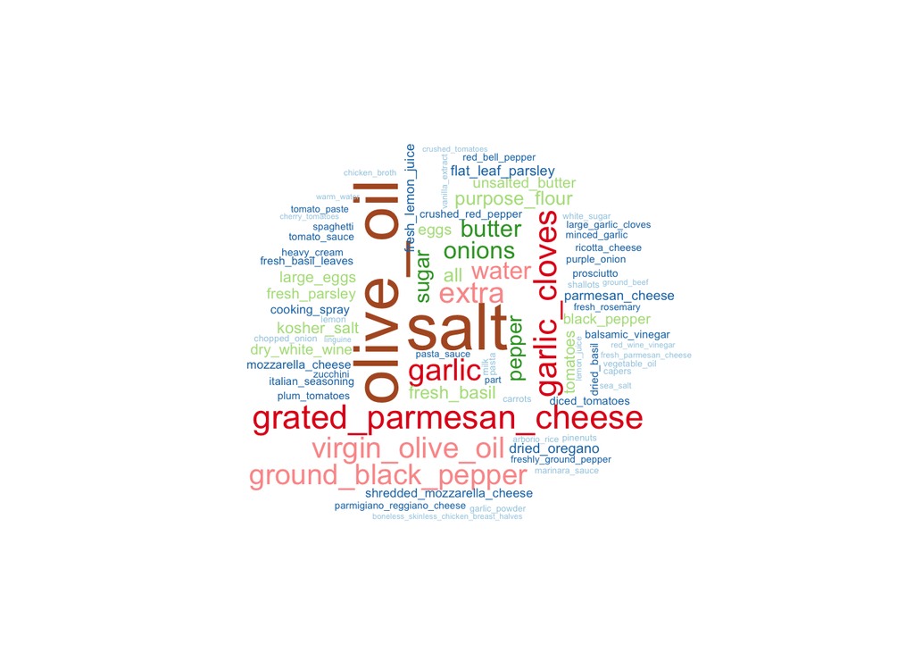

French It seems French cuisine uses more sugar and butter. Eggs and egg yolks are more commonly used. And the smaller texts show some sauces which are used more in French cuisine.

```
## [1] 2646  987
```

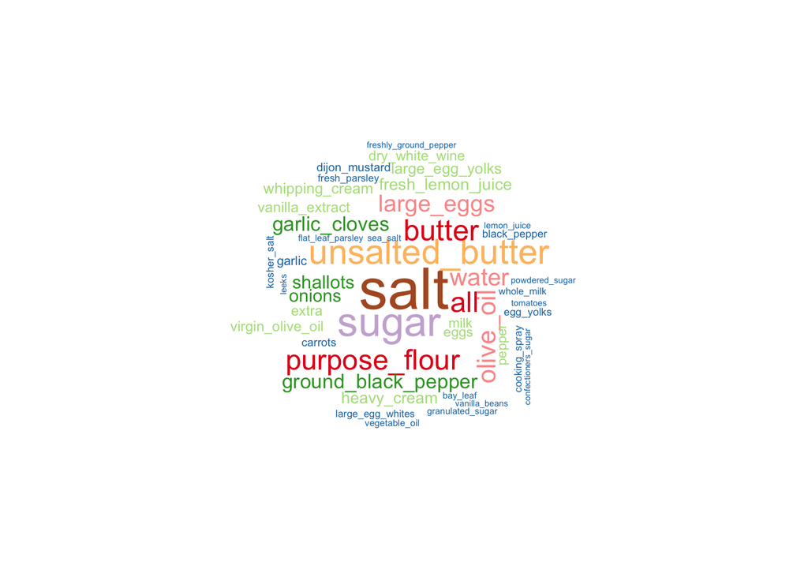

This one seems to be much salty and spicy. Chili, pepper, and garlic are more frequent in Mexican cuisine.

```
## [1] 6438  824
```

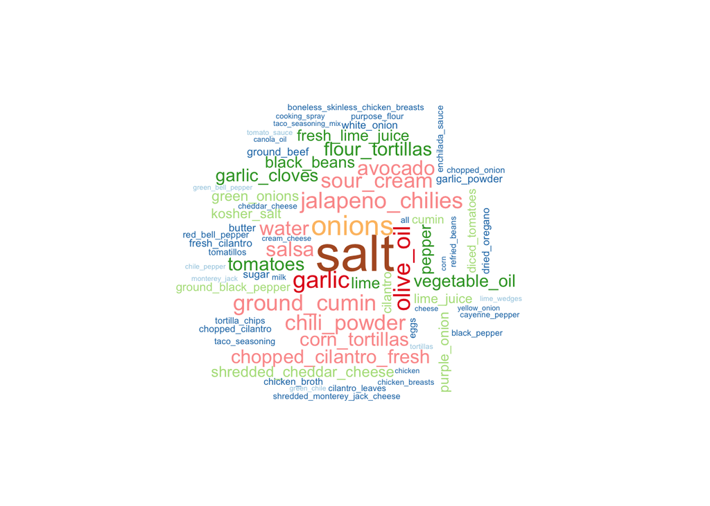

Let’s take a look at richmond area. This is the Southern US cuisine. Very simple!

```
## [1] 4320  847
```

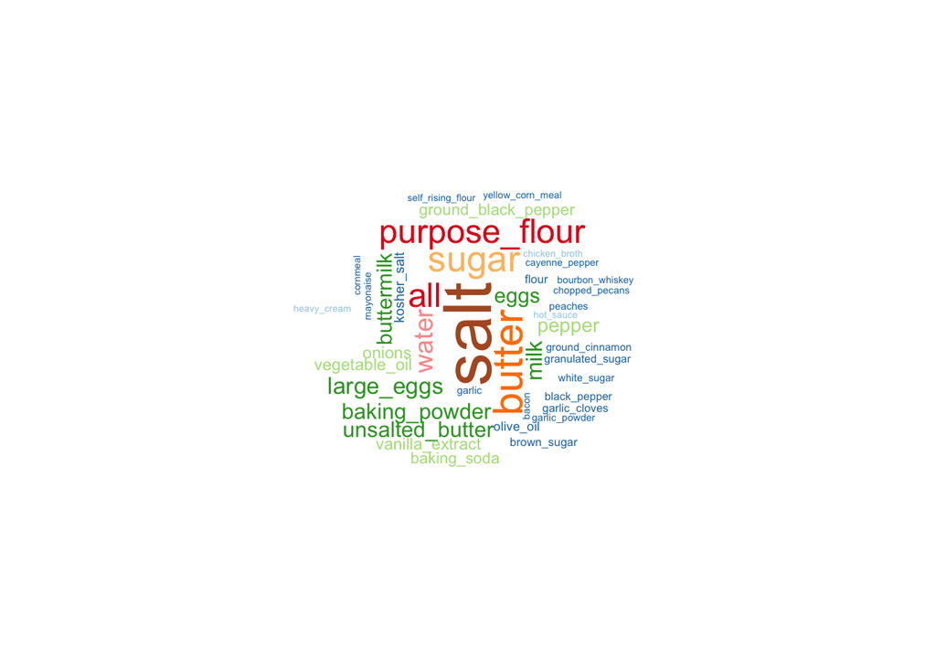

Soy sauce beat salt. This is very Asian. Vegetable oil and seasame oil appear rather than the olive oil. We have some green onions, fresh ginger, Chinese five… And then there are some chinese featured ingredients.

```
## [1] 2673  874
```

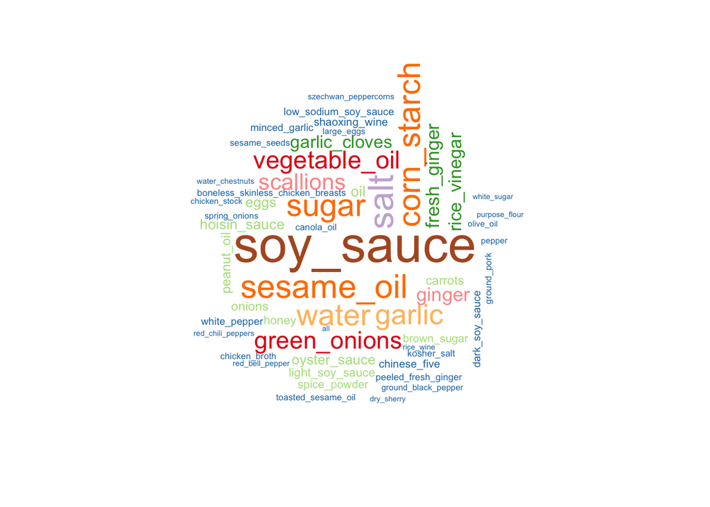

I think it is fun to just look at these ingredients and it gives me a better understanding of the different types of cuisines.

# Classification

## Glmnet

I first add class number, and divid the training and validation data set. Then I created the X matrix, with tokenize_words and `tokenize_ngram`. Here I not only filter the terms between 0.5% and 90%, I also scaled the rows of the data to count the frequencies.

```r
recipe$class <- as.numeric(as.factor(recipe$cuisine)) - 1
recipe$train_id <- sample(c("train", "valid"), nrow(recipe), replace = TRUE)

temp <- lapply(recipe$ingredients,
       function(v) stri_paste(stri_replace_all(v, " ", fixed = "_"), collapse = " "))
recipe$ingredients <- unlist(temp)

token_list <- tokenize_words(recipe$ingredients)
token_df <- term_list_to_df(token_list)
X1 <- term_df_to_matrix(token_df, min_df = 0.005, max_df = 0.90,
                       scale = TRUE)
dim(X1)
```

```
## [1] 39774   423
```

```r
token_list <- tokenize_ngrams(recipe$ingredients, n_min = 1, n = 4)
token_df <- term_list_to_df(token_list)
X2 <- term_df_to_matrix(token_df, min_df = 0.005, max_df = 0.90,
                       scale = TRUE)
dim(X2)
```

```
## [1] 39774  1139
```

```r
X <- cbind(X1, X2)

y <- recipe$class
X_train <- X[recipe$train_id == "train",]
X_valid <- X[recipe$train_id == "valid",]
y_train <- y[recipe$train_id == "train"]
y_valid <- y[recipe$train_id == "valid"]

library(glmnet)
model <- cv.glmnet(X_train, y_train, nfolds = 5, alpha = 0.9, family = "multinomial")
beta <- coef(model, s = model$lambda.1se)
beta <- Reduce(cbind, beta)
beta[apply(beta != 0, 1, any),][1:30,]
```

```
## 30 x 20 sparse Matrix of class "dgCMatrix"
```

```
##    [[ suppressing 20 column names '1', '1', '1' ... ]]
```

```
##
## (Intercept) -0.1732154  0.2928124  0.3214900 -0.28038725 -1.14981431
## pepper       .         -0.0566427  3.3312728  .           .
## salt         .          .         -4.5831880 -1.79773778  1.67939680
## oil          .         -0.6308846  .          7.09342794  .
## garlic       .         -7.6175798  .          .           7.27106516
## ground       .          .          .         -0.50282937  .
## fresh        .          .          .          .          -4.11946868
## sauce        .          .          .          6.61104788  .
## sugar        .          .          .          .           .
## onions       0.7083952  .          .          .           1.49008417
## cheese       .          .          .          .           .
## chicken      .         -9.1033569  .          4.37842668  3.56521820
## olive        .          .          .         -3.31022018  .
## black        .          .          .          .           .
## water        .         -1.6953414 -4.0884398  0.92621284  1.25114096
## red          .          .          .          2.42907020 -0.01802661
## flour        .          .          .          0.73428984  .
## butter       .          4.8380165  2.7045537 -4.18490328  .
## tomatoes     0.4241681 -2.4298472  .         -3.74499997  .
## green        .         -8.4550286  .          0.26735547  .
## powder       .          .          .          .           .
## chopped      .          .          .          .           .
## cloves       .          .          .          .           .
## juice        .          .          .         -0.52860513  .
## white        .          .          .          .           .
## onion        .          .          .         -0.65999455  .
## eggs         .          .          .          0.11570497  .
## cream       -0.3746513  8.6092075  .          .           .
## rice         .          .          3.5868471  5.82192864  .
## cilantro     7.1974668  .         -0.5634257  0.08279237  .
##
## (Intercept)  1.157817 -0.2753824  0.06027941 -0.150642  1.7687907
## pepper       .         .          .           .         .
## salt         .         .          1.79562061  .         .
## oil         -1.346857  .          .          -4.780021  .
## garlic       .         .          .          -2.620244  .
## ground       .         5.2578327  .           .         .
## fresh        .         .          .           .         2.4942731
## sauce       -3.778183  .         -0.97160879  .        -2.5213542
```

[output cut: 69 more lines]

```
## red          .           .           .           0.63691924  .
## flour        0.93071853  .          -1.30949144 -4.05042890  .
## butter       .           4.60716133 -4.32454578  .          -1.807029
## tomatoes     .           .           6.64185047 -4.25335664 -2.087195
## green       -1.25921377  .           .           .           .
## powder       .           .          -2.87162113  .           .
## chopped      .           .           0.06181116  .           .
## cloves       .          -0.02475814  .           .           .
## juice        .           .           1.69388592  .           .
## white        .           .           .           .           .
## onion        .           .           .           .           .
## eggs         4.48700621 -2.65375773  4.81855801  .          -6.149534
## cream        .           2.84032498  .           .           .
## rice        -0.21034234 -6.54149236  .           2.16324445  8.647034
## cilantro     .          -9.68453763  .          23.28896226 10.426549
```

```r
recipe$class_pred_glmnet <- predict(model, newx = X, type = "class")
tapply(recipe$class_pred_glmnet == recipe$class,
       recipe$train_id, mean)
```

```
##     train     valid
## 0.7786047 0.7362895
```

The result is pretty good for classifying 20 classes.

## XGBoost

Then I tried trees to catch the nonlinearity.

```r
token_list <- tokenize_words(recipe$ingredients)
#token_list[10]
token_df <- term_list_to_df(token_list)
#filter(token_df, id == 10)

X <- term_df_to_matrix(token_df,min_df = 0.005, max_df = 0.90, scale = TRUE)
y <- recipe$class

X_train <- X[recipe$train_id == "train",]
X_valid <- X[recipe$train_id == "valid",]
y_train <- y[recipe$train_id == "train"]
y_valid <- y[recipe$train_id == "valid"]

library(xgboost)
data_train <- xgb.DMatrix(data = as.matrix(X_train), label = y_train)
data_valid <- xgb.DMatrix(data = as.matrix(X_valid), label = y_valid)
watchlist <- list(train=data_train, valid=data_valid)

model <- xgb.train(data = data_train,
                 max_depth = 4, eta = 0.001, nthread = 2,
                 nrounds = 1000, objective = "multi:softmax",
                 watchlist = watchlist, num_class = 20,
                 print_every_n = 100)
```

```r
recipe$class_pred_xgb <- predict(model, newdata = as.matrix(X))
tapply(recipe$class_pred_xgb == recipe$class,
       recipe$train_id, mean)
```

```
##     train     valid
## 0.6688499 0.6419980
```

Confusion matrix:

```r
table(cuisine_pred = recipe$class_pred_xgb,
      cuisine = recipe$cuisine)
```

```
##             cuisine
## cuisine_pred brazilian british cajun_creole chinese filipino french greek
##           0        145       3            3       3       28      3     0
##           1          1     154            5      10        6     50     2
##           2          3       5          954       6        1     16     0
##           3          2       8            7    2178      180      8     4
##           4          5       2            1      10      216      4     0
##           5         14      81           61      60       49    794    17
##           6          2       5            8       2        0     18   692
##           7          5      23            7      11        5     19     6
##           8          2      33            5       1        2     43     1
##           9         97      94          173      61       47    976   304
##           10         3       3           12       0        1     17     3
##           11         1       1            5      51       13      4     0
##           12         1       0            0      49        5      1     0
```

[output cut: 51 more lines]

# Extension

The models did a pretty good job classifying different types of cuisines. So I think it might be interesting to let machine learning make some cuisines based on peoples preference and some robots can cook. It seems to be very productive. I found an interesting article: [A scientist is trying to teach a neural network to cook—and the results are hilariously bad](https://www.dailydot.com/unclick/neural-network-recipe-generator/)